# Bay Area Housing Market

Curtis Higa

## Question:

How does the Bay Area housing market compare to the rest of the United States?

- Since 2010, housing in the Bay Area has risen dramatically
  - Big tech region
  - High turnover rates
  - Political action considered
- Data sampled by zip codes

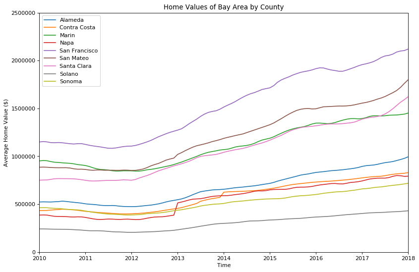

```python
plt.figure(figsize=(12, 8), dpi= 80, facecolor='w', edgecolor='k')

for county in bayarea_counties:
    plt.plot(grouped_ba[county], label = county)
plt.legend()
plt.title('Home Values of Bay Area by County')
plt.xlabel('Time')
plt.ylabel('Average Home Value ($)')
plt.axis(['2010','2018',0,2500000])
plt.show()
```

## 2018 Bay Area Housing Prices vs. United States

Below shows how Bay Area counties (red) compare to other U.S. counties

- All Bay Area counties above average
- 5 of top 10 counties are Bay Area counties

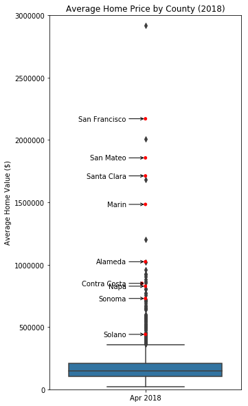

```python
plt.figure(figsize=(5, 10))
_ = sns.boxplot(data = grouped.loc['2018-04',:].transpose())
_ = sns.swarmplot(data = grouped_ba.loc['2018-04',:].transpose(), color = 'red')
_ = plt.title('Average Home Price by County (2018)')
_ = plt.xticks(range(1), ['Apr 2018'])
_ = plt.ylabel('Average Home Value ($)')
_ = plt.ylim([0, 3000000])
for label in bayarea_counties:
    _ = plt.annotate(label,
                    xy = (0, grouped_ba['2018-04'][label]),
                    xytext = (-0.1, grouped_ba['2018-04'][label]),
                    textcoords = 'data', ha = 'right', va = 'center',
                    arrowprops=dict(arrowstyle = '->'))
```

### 2018 Bay Area Housing Prices vs. United States: Significance

- Difference in mean housing price
  - Bay Area mean: \$1,301,955
  - United States mean: \$267,971
- Statistically and practically significant:
  - Bay Area prices are nearly five times as much as the national average by zip code.

## 2010-2018 Bay Area Housing Price Percent Change vs. United States

- Want to compare how counties have grown since end of Great Recession in 2010
  - Bay Area counties marked in red
- Percent change calculated:
  - $percent\_change = \frac{(April\_2018\_data) - (January\_2010\_data)}{(January\_2010\_data)}$

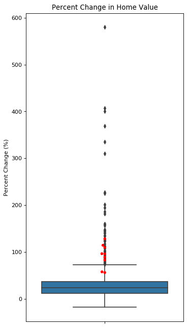

```python
plt.figure(figsize=(5, 10), dpi= 80, facecolor='w', edgecolor='k')

_ = sns.boxplot(pct_change[pct_change['change'] < 600]['change'], orient = 'v')
_ = sns.swarmplot(pct_change_ba['change'],
                  orient = 'v', color = 'red')
_ = plt.title('Percent Change in Home Value')
_ = plt.ylabel('Percent Change (%)')
```

### 2010-2018 Bay Area Housing Price Percent Change vs. United States: Significance

- Difference in mean percent change
  - Bay Area mean percent change: 95.2%
  - United States mean percent change: 28.8%
- Statistically and practically significant
  - Bay Area prices have nearly doubled on average
  - United States prices on average have hardly grown

## 2018 Bay Area Housing Prices by County

- Saw a gap in prices between cluster of counties
  - "Upper" tier counties
    - Marin
    - San Francisco
    - San Mateo
    - Santa Clara
  - "Lower" tier counties
    - Alameda
    - Contra Costa
    - Napa
    - Solano
    - Sonoma

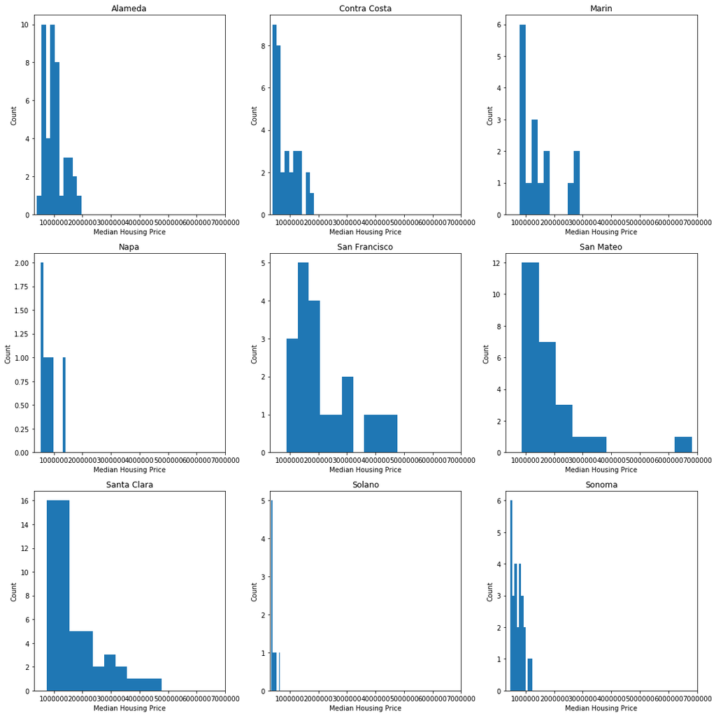

```python
# Plot distribution of median house prices by zip code by Bay Area county
plt.subplots(figsize = (15, 15))
for county in bayarea_counties:
    _ = plt.subplot(3, 3, bayarea_counties.index(county) + 1)
    _ = plt.hist(bay_area[bay_area['CountyName'] == county]['2018-04'])
    _ = plt.title(county)
    _ = plt.xlabel('Median Housing Price')
    _ = plt.ylabel('Count')
    _ = plt.xlim([300000,7000000])
    _ = plt.tight_layout()
```

### 2018 Bay Area Housing Prices by County: Significance

- There's seems to be gaps in house prices by county
  - "Upper" tier counties have higher house prices on average than the rest of Bay Area
    - Mainly reside on western side of the Bay Area
    - Big tech/business companies are headquartered
  - "Lower" tier county house prices (minus Solano county) are clustered under "upper" tier
  - Solano county has cheaper houses on average
    - Furthest away (not adjacent) from "upper" tier counties
- Statistically and practically significant
  - "Upper" tier county average almost twice "lower" tier county average

## 2010-2018 Bay Area Housing Price Percent Change by County

Compare how each countys' prices have changed since 2010

- Indication on their growth and relevance

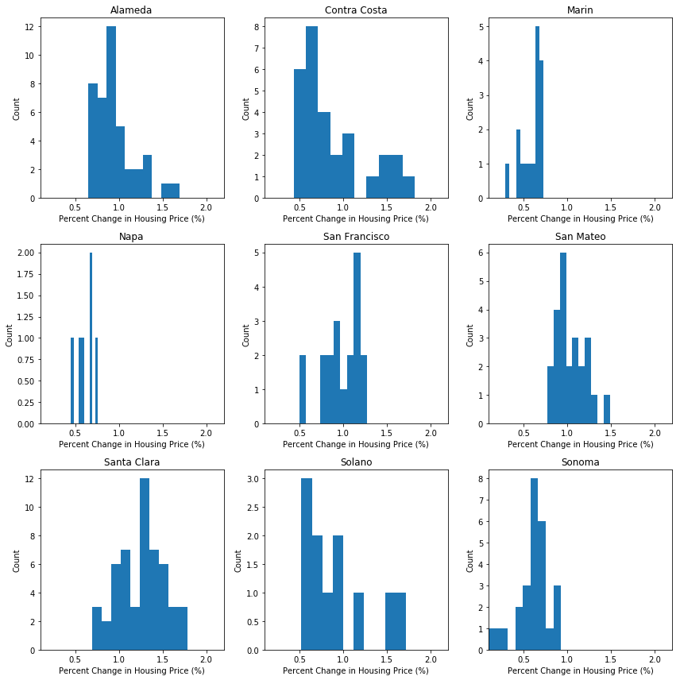

```python
# Plot the distribution of percent change per county by zip code
plt.subplots(figsize = (12, 12))
for county in bayarea_counties:
    _ = plt.subplot(3, 3, bayarea_counties.index(county) + 1)
    _ = plt.hist(ba_pc_county[ba_pc_county['CountyName'] == county]['change'])
    _ = plt.title(county)
    _ = plt.xlabel('Percent Change in Housing Price (%)')
    _ = plt.ylabel('Count')
    _ = plt.xlim([0.1, 2.2])
    _ = plt.tight_layout()
```

### 2010-2018 Bay Area Housing Price Percent Change by County: Significance

- Significant gaps appear
  - 3 North Bay counties (Marin, Napa, and Sonoma) are clustered together with the smallest percent change
    - All hover aroung 60% change
  - 5 counties (Alameda, Contra Costa, San Francisco, San Mateo, and Solano) clustered in the middle
    - Range from 89% to 104% change
  - Santa Clara county seen the biggest significant change
    - Saw 126% change since 2010
- Practical Significance
  - Santa Clara is grew/growing twice as fast as the 3 North Bay counties
  - All Bay Area counties grew faster than the national average

## ARIMA Model

- Autoregressive Integrated Moving Average
  - 3 parameters
    - p: Autoregressive terms
    - d: Differencing order
    - q: Moving average terms

### Model Fitting

- Requires stationary data
- Data starts are January 2012
- Train/test split 70:30

## Alameda County

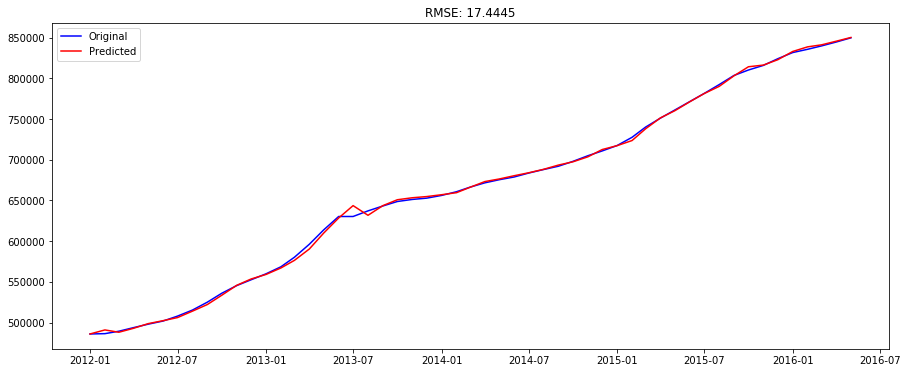

```python
ARIMA_predictions('Alameda', alameda_model_fit)
```

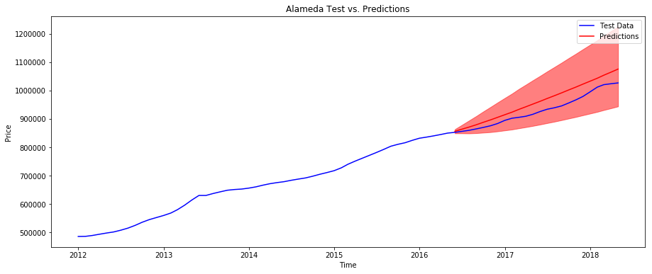

```
Test RSME: 32833.5954
```

```python
forecast_score('Alameda', alameda_model_fit)
```

- Fairly good predictions
- Gradual rise in prices

## Contra Costa County

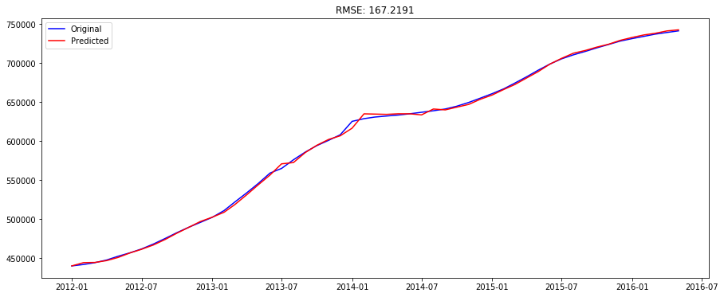

```python
ARIMA_predictions('Contra Costa', cc_model_fit)
```

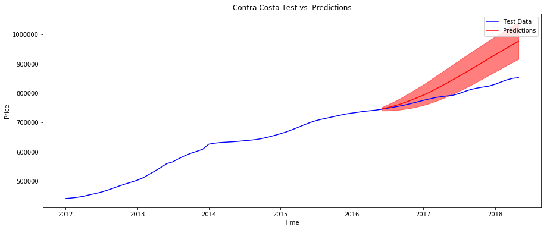

```
Test RSME: 65787.7739
```

```python
forecast_score('Contra Costa', cc_model_fit)
```

- Poor model predictions
  - Parameter tuning
  - Stationary data set

## Marin County

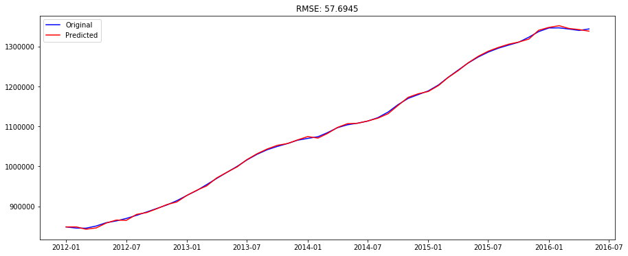

```python
ARIMA_predictions('Marin', marin_model_fit)
```

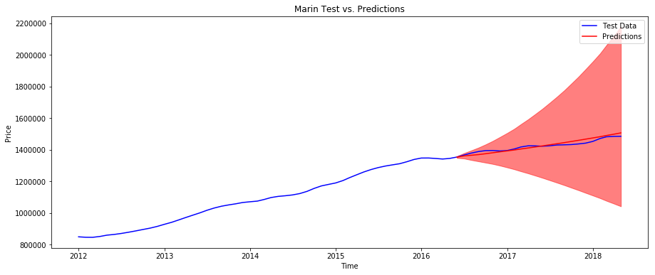

```
Test RSME: 14160.5829
```

```python
forecast_score('Marin', marin_model_fit)
```

- Good model
- Growing confidence interval
  - Not good for long term predictions

## Napa County

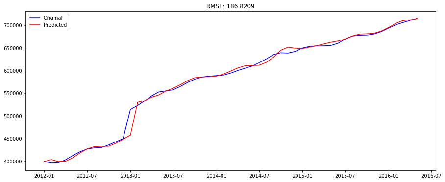

```python
ARIMA_predictions('Napa', napa_model_fit)
```

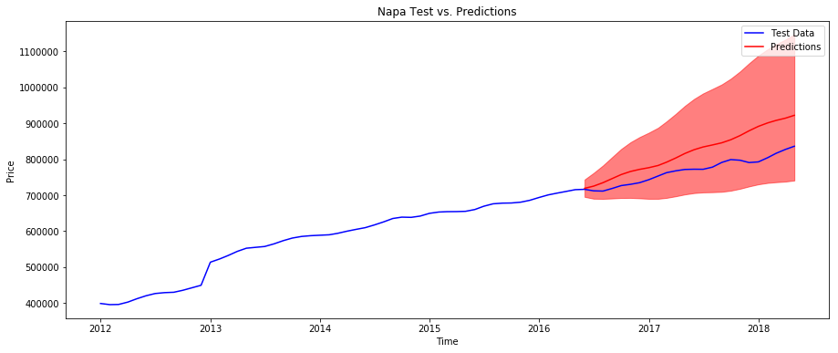

```
Test RSME: 58725.6706
```

```python
forecast_score('Napa', napa_model_fit)
```

- Fairly good model
- Test data lies within confidence interval

## San Francisco County

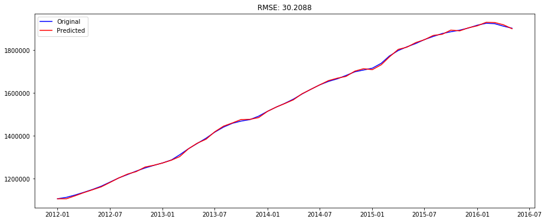

```python
ARIMA_predictions('San Francisco', sf_model_fit)
```

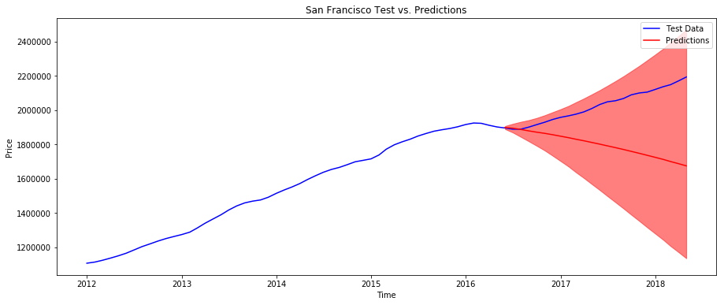

```
Test RSME: 275504.6893
```

```python
forecast_score('San Francisco', sf_model_fit)
```

- Poor model
  - Poor predictions
  - Growing confidence interval
- More stationary data
- Parameter tuning

## San Mateo County

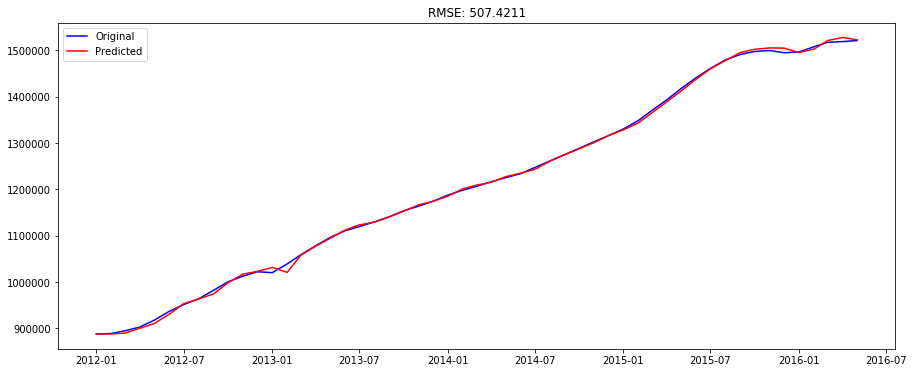

```python
ARIMA_predictions('San Mateo', sm_model_fit)
```

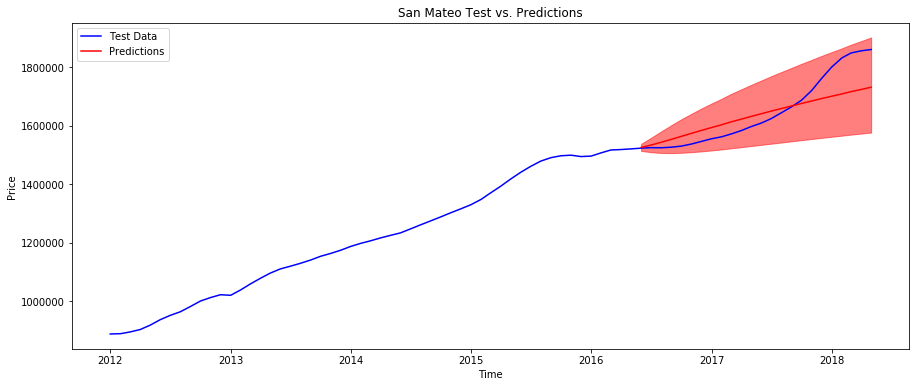

```
Test RSME: 63677.1799
```

```python
forecast_score('San Mateo', sm_model_fit)
```

- Fair model
- Predicts overall trend
- Erratic test data

## Santa Clara County

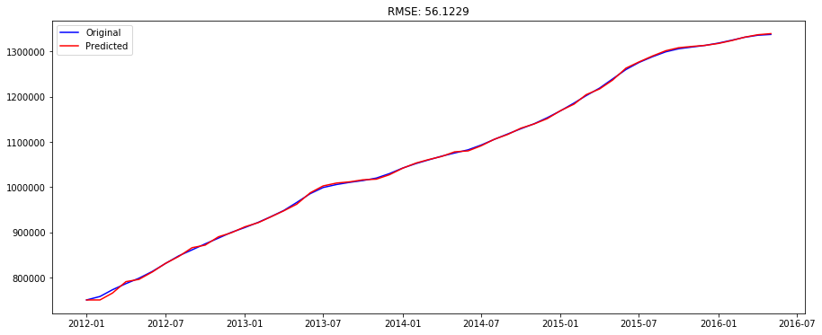

```python
ARIMA_predictions('Santa Clara', sc_model_fit)
```

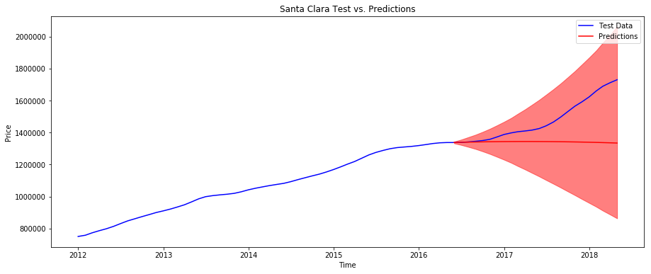

```
Test RSME: 185958.1838
```

```python
forecast_score('Santa Clara', sc_model_fit)
```

- Poor model
  - Predicts flat trend
  - Growing confidence interval
- More stationary data

## Solano County

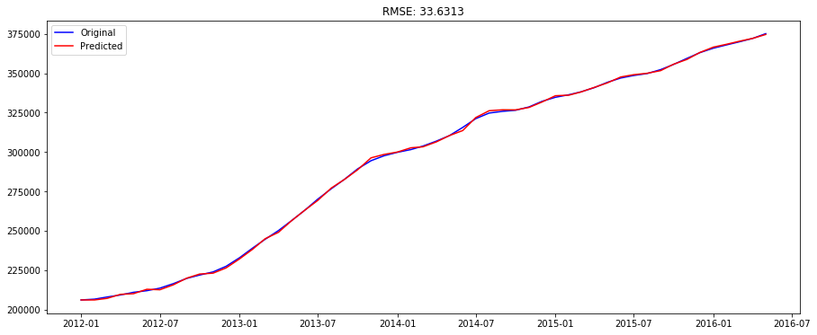

```python
ARIMA_predictions('Solano', solano_model_fit)
```

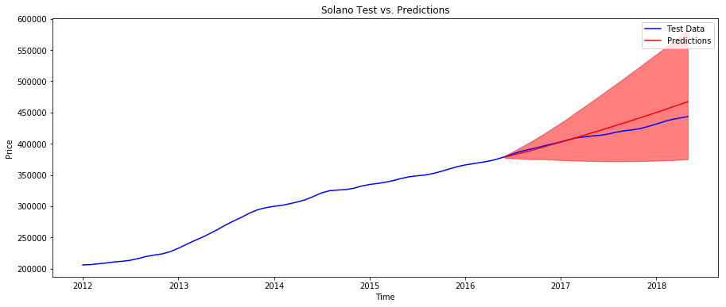

```
Test RSME: 12061.3198
```

```python
forecast_score('Solano', solano_model_fit)
```

- Good model
- Predicts growing trend

## Sonoma County

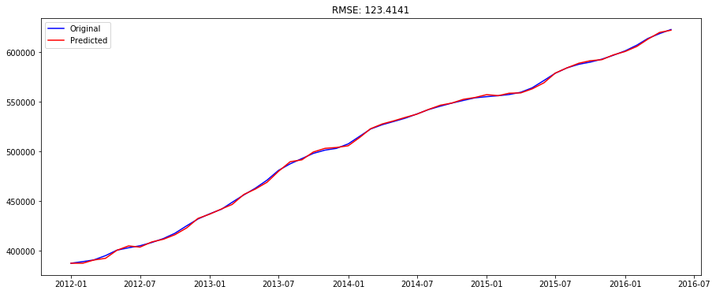

```python
ARIMA_predictions('Sonoma', sonoma_model_fit)
```

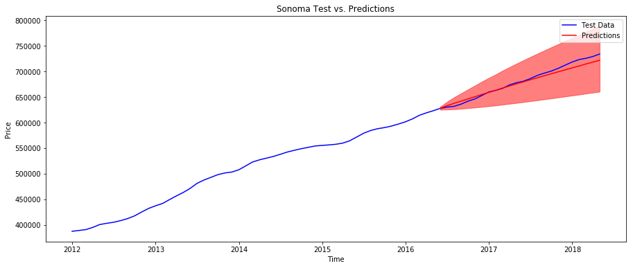

```
Test RSME: 6526.3201
```

```python
forecast_score('Sonoma', sonoma_model_fit)
```

- Good model
- Predicts growing trend

## Bay Area Conclusions

- Most counties are predicted to rise
- Models could use tuning
  - More stationary data
  - More data
  - Parameter tuning